# Analyzing and Predicting Crime in Chicago

In this project, I consider the Redeye Chicago homicide dataset that tracks homicides in Chicago since 2007, and the crime dataset from the Chicago data portal, which contains over 5.5 million records of crime that occurred in Chicago since 2001. Although the Chicago crime dataset also contains homicide data, the Redeye Chicago dataset contains much more detailed information such as the age and race of the victims. Along with the data on crimes, datasets from the census and weather provide information on demographics, socioeconomic factors and temperature.

The main motivations of this project are to provide an analysis of crime trends and patterns, and to provide a prediction of crime occurrence by location and time. The analysis reveals that overall crime is steadily decreasing, and drug and violent crimes have decreased the most in the past 10 years. The crimes are negatively correlated with income, that is, overall crime rate is higher is poor communities. However, the proportion of property crimes is higher in communities with high income.

The limited resources of the police department could be deployed much more effectively if we could predict ahead of time when and where crimes are likely to occur. My crime prediction shows that past history of crime trends, in other words, when and where crimes tended to occurr in the past, joined with the daily temperature data, can provide guidance in how to deploy police officers across communities and shifts quite well, with a Spearman's rank correlation coefficient of 0.8.

The source for the below analyses is [here](http://162.243.56.71:8000/src/chicago_crime_src.html).

## Homicides in Chicago

Chicago is notorious for gun violence and homicides; however, not all of its residents are affected equally. The data paints a stark picture of the demographics of homicide victims in Chicago.

### Homicide numbers from 2007 to 2013

```python
from IPython.display import Image
```

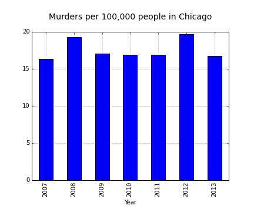

```python
Image(filename = '../figs/murders.png')
```

The rate of murder per 100,000 people in Chicago between 2007 and 2013 has been broadly consistent at around 17, but with peaks in 2008 and 2012 reaching almost 20. For comparison, the murder rate is 4.7 in the U.S. as a whole (2011), 6.3 in New York City (2011), and 7.8 in Los Angeles (2012).

### Murder rates by race, gender, and age of victim

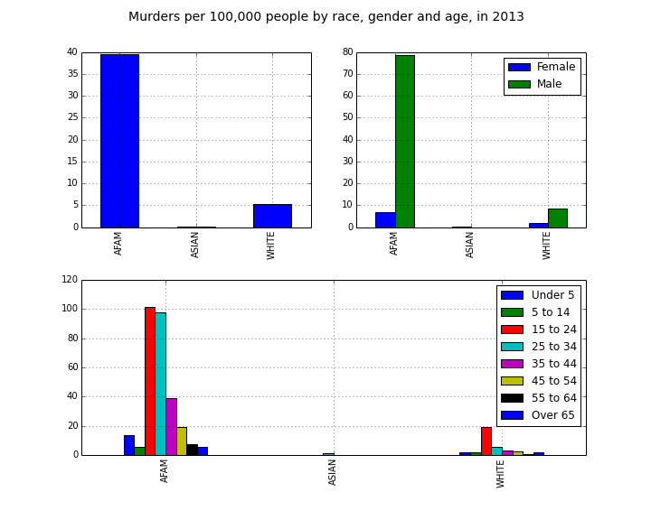

```python
Image(filename = '../figs/murders_grouped.png')
```

The race categories are Asian, African American, and White (White includes the hispanic/latino population). Gunshot is the main cause of homicides by far, with stabbing coming second. The homicide victims are overwhemingly African American men: almost 80 out of every 100,000 African American men in Chicago are murdered each year, while the rate for white men is around 10 out of every 100,000. The rate for African American women is a tenth of that for African American men (about 8 per 100,000) and that for white women is 2 per every 100,000.

African American men between 15 and 24 of age is the most vulnerable group. Over 100 out of every 100,000 African American men in this age group gets murdered each year, 98% from gunshot wounds. Together, African American men of ages beteen 15 and 34 make up 56% of the total murder victims in Chicago.

### Murders by communities

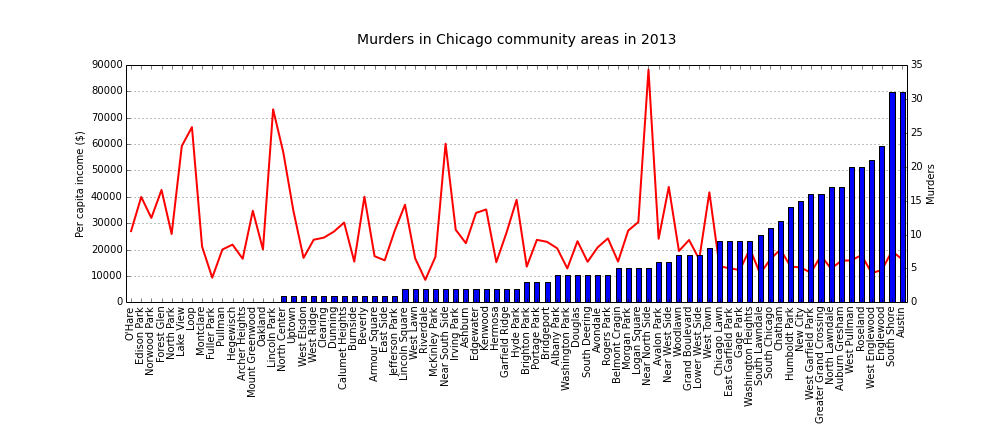

```python
Image(filename = '../figs/murders_ca.png')
```

The city of Chicago is divided into 77 community areas. Murders are strongly segregated by community: 15% of total murders that occurred in Chicago in 2013 were in just two community areas, Austin and South Shore. These two communities account for only 5.5% of the total population of Chicago. The 10 communities with the highest number of murders together make up 48% of the total murders in Chicago in 2013, while having 16% of the population. The plot shows that the communities with the highest number of murders are also those that have the lowest income.

## Overall Trends in Crime

### Overall rate of crime in Chicago between 2004 and 2013.

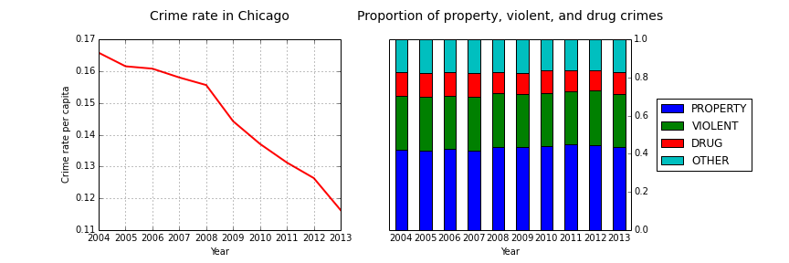

```python
Image(filename = '../figs/crimes.png')
```

The overall crime rate in Chicago has been steady decreasing between the years 2004 and 2013. The proportions of property, violent, and drug crimes are broadly constant over the years, although the proportion of property crimes has increased slightly since 2008 while the proportion of drug crimes has decreased.

Violent crimes are are those committed directly against a person: homicide, criminal sexual assault, robbery, and aggravated assault/battery. Property crimes are those in which there is no direct threat or harm to a person - burglary, theft, motor vehicle theft, criminal damage, and arson.

### Which crimes have decreased the most/least between 2004 and 2013?

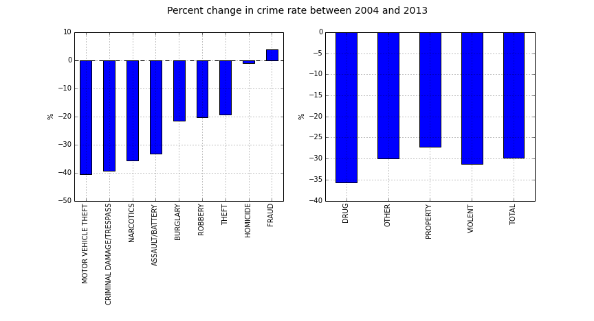

```python
Image(filename = '../figs/crimes_change.png')
```

Most crimes have decresed in the 10 years to 2013, but fraud shows a small increase. Among crime types, drug crimes have decreased the most, while property crimes have decreased the least.

`*`The population of Chicago for each year was obtained by linearly interpolating between the populations at 2000 and 2010.

### Which communities have the highest/lowest occurrence of crime?

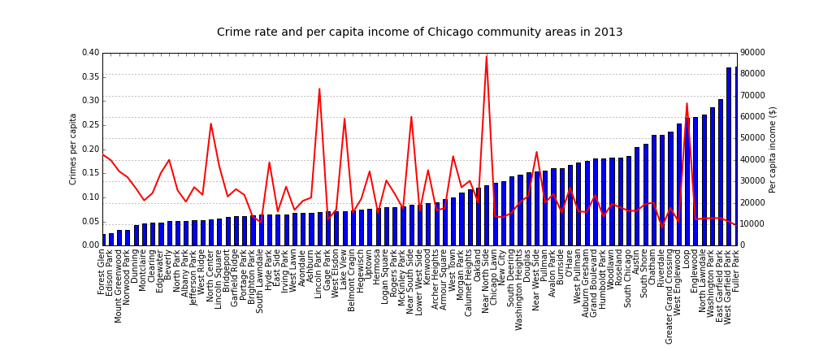

```python
Image(filename = '../figs/crimes_area.png')
```

Broadly speaking, the overall crime rate increases with decreasing income. However, there are some areas with high income (peaks in the per capita income curve) that have relatively high crimes rates. The types of crimes that occur gives us some idea as to why.

`*`The data for the per capita income of Chicago community areas was downloaded from the Chicago data portal.

### Which crimes tend to occur in certain communities?

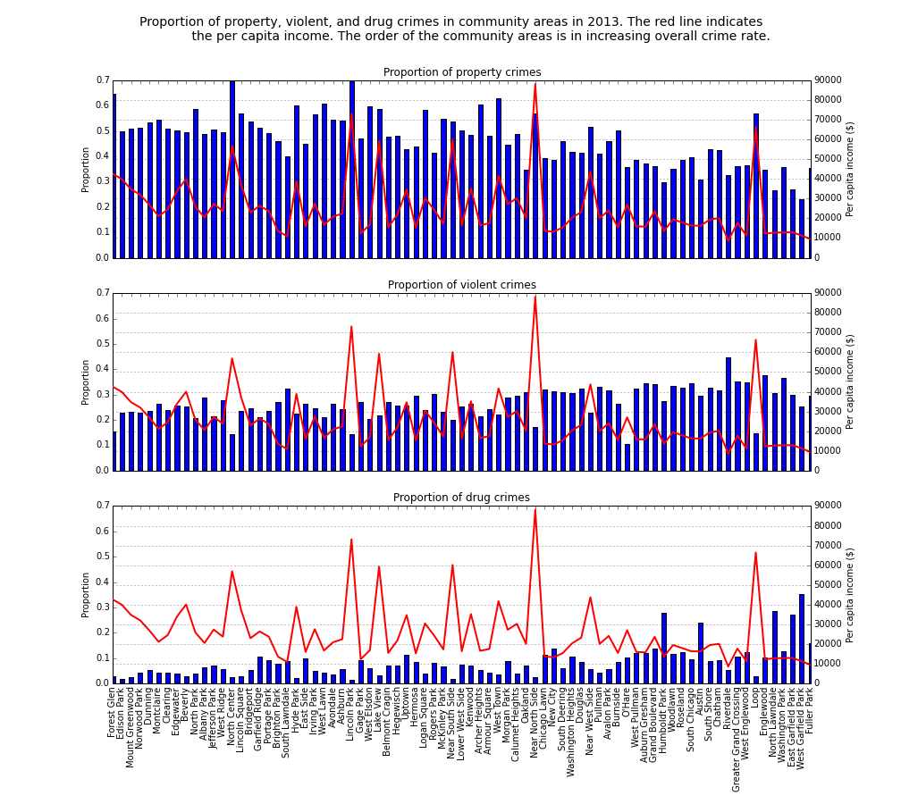

```python
Image(filename = '../figs/crimes_area_grouped.png')
```

The plots indicate that the proportion of property crimes tends to increase with income, while the proportions of violent and drug crimes decrease with increasing income. This is corroborated by considering the Spearman's rank correlation coefficient between per capita income and proportion of a particular type of crime. The coefficient measures how well the relationship between two variables can be described using a monotonic function. A value of 1 or -1 indicates each of the variables is a perfect monotonically increasing or decreasing function of the other. The coefficients are 0.66, -0.65, and -0.71, respectively, for the correlation between per capita income vs. proportion of property, violent, and drug crimes.

### Which types of crimes have the highest arrest rate?

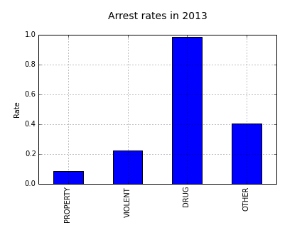

```python
Image('../figs/arrest.png')
```

Arrest rates in general are pretty low, about 20% for violent crimes and 9% for property crimes. The exception is drug crime, where the arrest rate is close to 100%. This is due to the nature of drug crime, which is rarely reported.

### Which neighborhoods have the highest/lowest arrest rate?

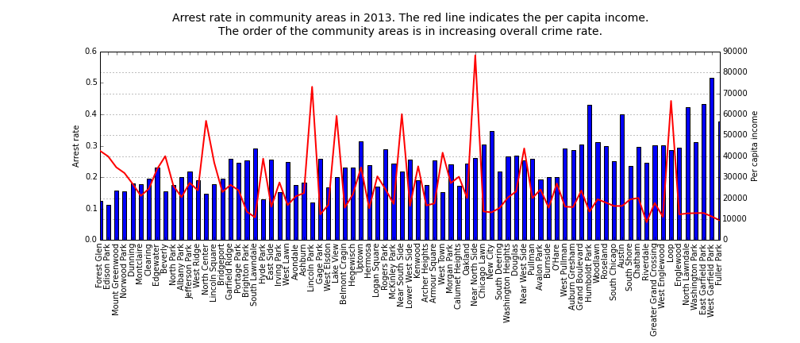

```python
Image('../figs/arrest_grouped.png')
```

The neighborhoods with more crime tends to have higher arrest rates, with a spearman's rank correlation coefficient of 0.71. The income level has a negative correlation with the arrest rate, probably due to the fact that high income communities have less crime. But is the larger proportion of drug crimes in less affluent communities skewing the results? I consider the arrest rate of non-drug crimes below to answer this question.

#### What if we consider only the non-drug crimes?

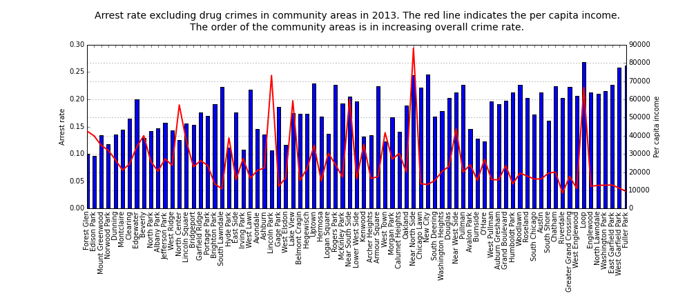

```python
Image('../figs/arrest_grouped_ndrug.png')
```

The rank correlation coefficient of non-drug crimes and arrest rate is 0.6, definitely smaller than that for all crimes, but still indicative that more arrests occurr in neighborhoods with more crimes, even when drug crimes are excluded. There is a smaller negative rank correlation between arrest rate and income when drug crimes are excluded.

### Crime Prediction

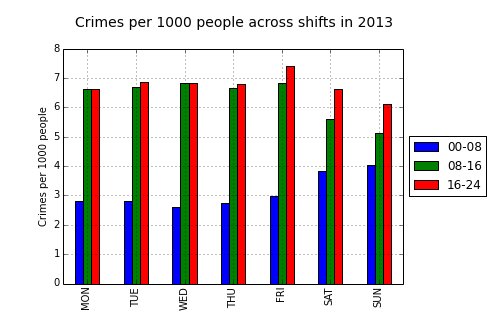

```python
Image('../figs/crimes_trend.png')
```

Dividing each day into three 8-hour shifts that closely follow actual police shifts, I consider the variation of crime rate on day of week and time of day. The week divides into 21 shifts, and the above plot shows that there is a clear pattern of crime rate being higher during the evening hours, and on weekends. Crimes rates are highest on Friday evenings. During the night (between midnight and 8 am), crime rates are highest on Saturdays and Sundays; however, crimes rates are lowest on those days between 8 am and midnight.

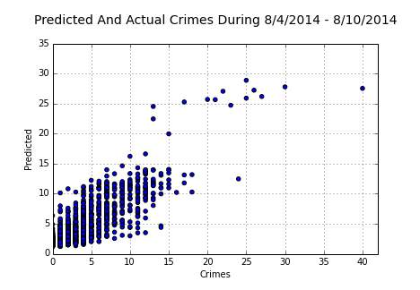

```python
Image('../figs/predict.png')
```

The prediction was based on a linear regression of the following features: the community area, day of week, time of day (each day is divided into three shifts as above), the maximum and minimum temperatures of the day. The data from the previous five-year period (8/4/2009 - 8/3/2014) was used to predict crime occurrence during this particular week. A perfect prediction would have the points lined up along the diagonal line of the plot.

Since I was mainly interested in being able to predict in which community area or shift police officers should be focusing on, I chose Spearman's rank correlation coefficient as the metric for the regression. This measures how well the relationship between two variables can be described using a monotonic function, so that for example, the 10 communities with highest predicted crime would be likely to coincide with the 10 communities that actually have the most crimes committed.

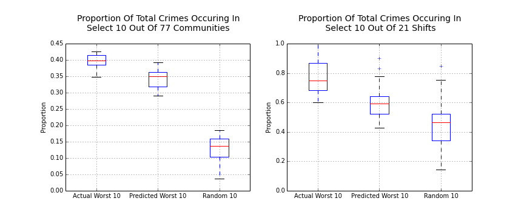

```python
Image('../figs/summary.png')
```

The utility of predicting crimes lies in being able to deploy police officers ahead of time so as to maximize their effectiveness. A measure of how well the prediction performs in this sense is shown in the above plots. The figure on the left shows how well the prediction does in allocating police officers to different communities for each 8 hour shift during the week. Let's assume that the strategy is to select 10 out of the 77 communities of Chicago and concentrate all the police efforts upon these 10. For a particular 8 hour shift during the week of Aug. 4th, randomly selecting 10 communities would result in targeting only 12% of the total crimes that were committed during that shift, on average. Selecting the 10 communities with the highest predicted number of crimes results in 34% of the crimes being targeted, while the best-case scenario, when you know ahead of time which 10 communities would have the highest number of crimes committed, would result in 40% of the crimes being targeted, on average.

It is likely that the police officers in one community cannot easily be deployed in another. In this case, the figure on the right shows how best to allocate officers in each community to different shifts. For this scenario, let's assume that the strategy is to concentrate police efforts on 10 out of the 21 shifts during the week. For a particular community area, randomly selecting 10 shifts would target 50% of the total crimes committed during the week in that community area, on average. Selecting the 10 shifts with the highest predicted number of crimes results in 60% of the crimes being targeted, while the best-case scenario, where you know in which 10 shifts the highest number of crimes would be commited ahead of time, would result in 75% of crimes being targeted, on average.

The crime maps can be seen for Tuesday 00 to 08 (https://jee.cartodb.com/tables/aug_5_2014_tuesday_00_08/map), Friday 16 to 24 (https://jee.cartodb.com/tables/aug_8_2014_friday_16_24/map), and Saturday 08 to 16 (https://jee.cartodb.com/tables/aug_9_2014_saturday_08_16/map)